# Interactive data visualization on the web using R

2016-12-12  
This work is released under [Creative Commons](https://github.com/cpsievert/talks/blob/gh-pages/LICENSE)

## Bio

- Teaching Assistant, **Iowa State University** (2011-2015)
- M.S. in Statistics, **Iowa State University** (2013)
- Internships with AT&T (2013) and Google (2014)
- Software Developer, **plotly** (2015 - Present)
- Research Assistant, **Monash University** (Sept 2015 - June 2016)

[figure not shown]

## Future plans

#### Freelance software developer & data scientist

- My clients already include: plotly, NOAA, Phronesis
- In addition to developing **plotly**, I plan on delivering "data products" (e.g. interactive web apps, dynamic reports/documents, etc.)
- Businesses already building products around **plotly**: [Omni Analytics](https://omnianalytics.io/), [TCBD Analytics](http://tcbanalytics.com/)

## Why interactive/dynamic graphics?

- Why interactive/dynamic graphics for **presentation**?
  - Enhances knowledge transfer in some way (see [New York Times](http://www.nytimes.com/interactive/2015/us/year-in-interactive-storytelling.html), [USA Today](http://www.usatoday.com/topic/E01C4890-85A2-4E0B-A3DD-58BD88E71251/interactive-graphics/), [538](http://fivethirtyeight.com/features/gun-deaths/), [setosa](http://setosa.io/))
- Why interactive/dynamic graphics for **exploration**?
  - Identify structure that might otherwise go missing ([Tukey 1972](http://stat-graphics.org/movies/prim9.html))
  - Find Gestalt, pose queries, & make comparisons ([Cook, Buja, & Swayne 2007](https://www.jstor.org/stable/1390754))
  - Explore, understand, & diagnose statistical model fit(s) ([Wickham, Cook, & Hofmann 2015](http://onlinelibrary.wiley.com/doi/10.1002/sam.11271/abstract)).
  - **Generate insights faster (iteration time is crucial!)**
- Why *web* graphics?
  - simple to share, portable (web browser)
  - encourages composability

## 2016 Election Outcomes by County ([source](http://rpubs.com/dgrtwo/county-results))

```
     County |   State | TotalVotes| Clinton| Johnson| Stein| Trump| Population|    Area
    --------| --------| ----------|--------|--------|------|------|-----------|--------
1   autauga | alabama |      24661|   0.240|   0.022| 0.004| 0.734|      54571|  594.44
2   baldwin | alabama |      94090|   0.196|   0.026| 0.005| 0.774|     182265| 1589.78
3   barbour | alabama |      10390|   0.467|   0.009| 0.002| 0.523|      27457|  884.88
4      bibb | alabama |       8748|   0.214|   0.014| 0.002| 0.770|      22915|  622.58
5    blount | alabama |      25384|   0.085|   0.013| 0.004| 0.899|      57322|  644.78
6   bullock | alabama |       4701|   0.751|   0.005| 0.002| 0.242|      10914|  622.81
7    butler | alabama |       8685|   0.428|   0.007| 0.001| 0.563|      20947|  776.83
8   calhoun | alabama |      47376|   0.279|   0.024| 0.006| 0.692|     118572|  605.87
9  chambers | alabama |      13778|   0.418|   0.012| 0.003| 0.566|      34215|  596.53
10 cherokee | alabama |      10503|   0.145|   0.014| 0.002| 0.839|      25989|  553.70
# ... with 3,101 more rows
```

- Is there a relationship between population density and voting preference?

[interactive chart not shown]

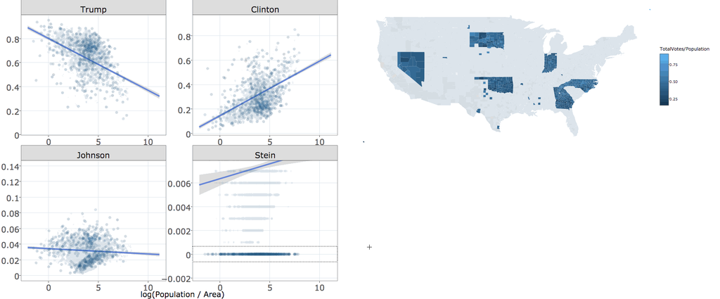

## The problem with exploratory web graphics

- Web graphics are useful for conveying information (viz is *known*), but often impractical for exploration (viz is *unknown*).

[figure not shown]

## The plotly ecosystem

[figure not shown]

## R packages for interactive web graphics

- Many R packages allow you create web graphics
  - A few attempt to be general purpose
    - **rCharts** (Vaidyanathan et al. 2014), **ggvis** (Chang and Wickham 2016), **rBokeh** (Hafen et al. 2016)
  - More common to see "specialized" graphics
    - **leaflet** (Cheng et al. 2016), **dygraphs** (Allaire et al. 2016), **networkD3** (Gandrud et. al. 2016), **DiagrammeR** (Iannone et al. 2016), **d3scatter** (Cheng 2016)
- Most approaches neglect/ignore linking views and animation.
  - **ggvis** has some linking/animation, but requires a shiny server.
  - **animint** (Hocking et al. 2016) supports linking/animation by extending **ggplot2**'s grammar of graphics implementation (Wickham et al. 2017).

## R packages for interactive web graphics

- **plotly** (Sievert el al. 2016) borrows ideas/foundations from **animint**.
  - Can also make **ggplot2** graphics interactive.
  - Also supports linking/animation.
  - Better support for focusing and arranging views.
  - A "non-ggplot2" interface helps support visualizations not supported by ggplot2 (e.g., 3D charts).
  - More interaction types (mouse hover, click, click & drag).
  - Dynamic linked brush coloring (useful for making comparisons).

## Demo

[See here](https://github.com/cpsievert/talks/tree/gh-pages/20161212a) for the demo script.

## Future work

- Extensions for more popular **ggplot2** packages such as **ggrepel** **ggraph**.

## Thank you

- Slides – http://bit.ly/phd-seminar